# Managing your data

Let’s fix a few new details to our plot. It could use better axis labels and a clear title. It could also be nice to change the color of the points to make them stand out a bit more:

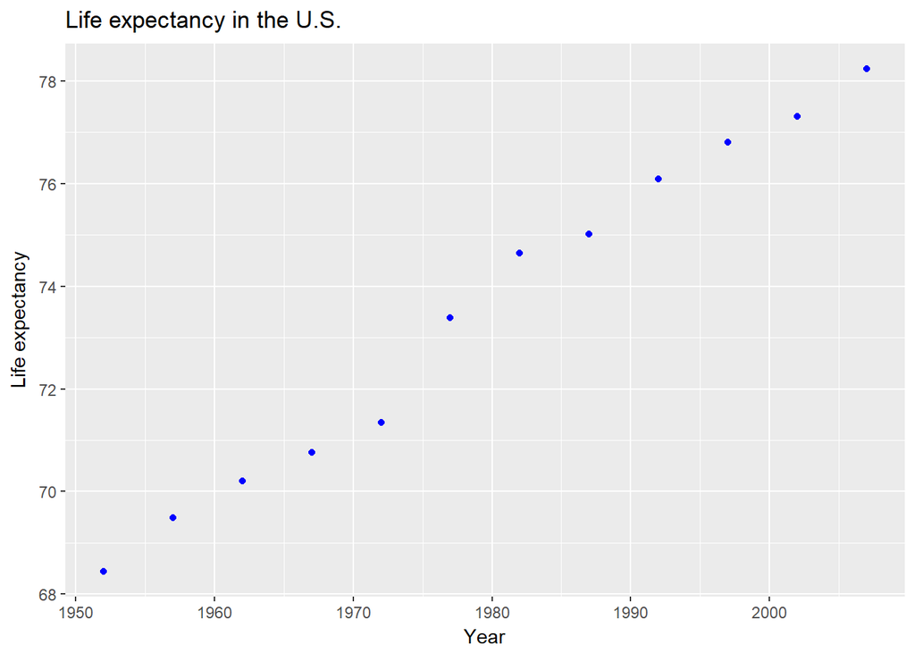

```r
ggplot(data=us) +
  geom_point(mapping = aes(x = year, y = lifeExp), color = "blue") +
  ggtitle("Life expectancy in the U.S.") +
  xlab("Year") +
  ylab("Life expectancy")
```

Much better. Depending on what we want to plot, we can change the geometry object we use. If we want a smoothed line plot, we could use `geom_smooth`:

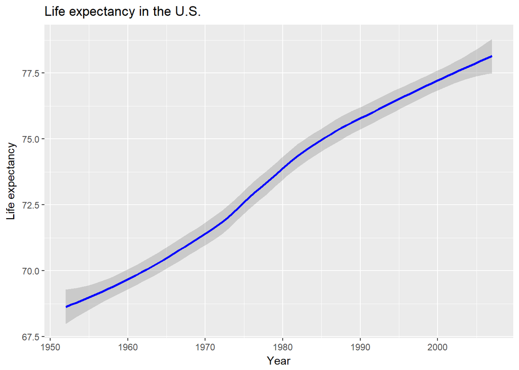

```r
ggplot(data=us) +
  geom_smooth(mapping = aes(x = year, y = lifeExp), color = "blue") +
  ggtitle("Life expectancy in the U.S.") +
  xlab("Year") +
  ylab("Life expectancy")
```

Another cool trick is that we can pipe `%>%` our `dplyr` manipulations straight into a `ggplot()`. Let’s make a life expectancy plot for Sierra Leone using this approach:

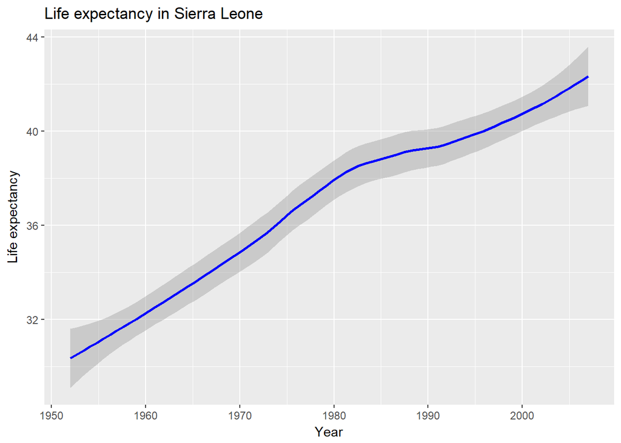

```r
gapminder %>%
  filter(country == "Sierra Leone") %>%
  ggplot() +
  geom_smooth(mapping = aes(x = year, y = lifeExp), color = "blue") +
  ggtitle("Life expectancy in Sierra Leone") +
  xlab("Year") +
  ylab("Life expectancy")
```

What if we wanted to compare life expectancy in the United States with life expectancy in Sierra Leone in a single plot?

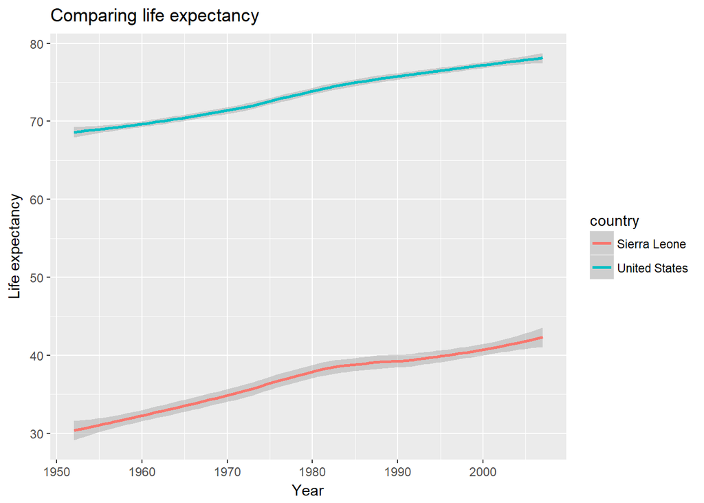

```r
gapminder %>%
  filter(country %in% c("Sierra Leone", "United States")) %>%
  ggplot() +
  geom_smooth(mapping = aes(x = year, y = lifeExp, color = country)) +
  ggtitle("Comparing life expectancy") +
  xlab("Year") +
  ylab("Life expectancy")
```

If you want to filter using multiple criteria, use `%in%` rather than `==`. This selects all rows with `country` equal to the countries in the list we created using `c()`. Since our `data.frame` contains information from two countries, we can add an argument to the `geom_smooth()` function that tells `ggplot()` to group observations by country and to symbolize them using two different colors. We do this by adding the argument `color=country`.

# Additional resources

- In this lab, I’ve reviewed how to subset and wrangle your data using `dplyr`. You can also do this in base `R` and it’s often quite useful to know how to do this. I recommend the learnR tutorial or these tutorials on [data subsetting](http://swcarpentry.github.io/r-novice-gapminder/06-data-subsetting/), [data manipulation](http://swcarpentry.github.io/r-novice-gapminder/05-data-structures-part2/). Make sure you’re familiar with how to index and wrangle data in base `R` before we proceed!
- For more complex data merges and joins, check out [this overview](http://stat545.com/bit001_dplyr-cheatsheet.html).